# Route Stuff

Nathan Hoteling

3/8/2022

## Data Simulations

A simulated dataset is generated from the travel route between Portland, OR and Portland, ME. City coordinates are obtained from OpenStreetMap via `osmdata` and the route between cities from `osrm`,

```r
# Coords for  Portland, OR
pdx <- osmdata::getbb("Portland, OR", format_out="sf_polygon")
pt_pdx <- pdx$multipolygon %>% sf::st_centroid()

# Coords for Portland, ME
ptm <- osmdata::getbb("Portland, ME", format_out="sf_polygon")
pt_ptm <- ptm$multipolygon %>% sf::st_centroid()

# Route from Portland to Portland
df.rte <- osrm::osrmRoute(src=pt_pdx, dst=pt_ptm) %>%
  mutate(pt = crd_to_points(lon,lat))
```

The simulated dataset is generated from five hundred imaginary trips. For each trip noise is added by sampling from a Normal distribution with centroid value being the point coordinates.

```r
# Simulate some data
N <- 500
set.seed(1234)  # So random numbers are repeatable
d <- lapply(1:nrow(df.rte), function(i) {
  lon <- rnorm(N,df.rte$lon[i]) #+ rbinom(N,3,0.2)
  lat <- rnorm(N,df.rte$lat[i]) #+ rbinom(N,2,0.2)
  idx_tr <- 1:N
  idx_pt <- i
  data.frame(lon=lon, lat=lat,idx_tr=idx_tr, idx_pt=idx_pt)
})
df.dat <- do.call(rbind,d) %>%
  mutate(pt = crd_to_points(lon,lat),
         hex = h3::geo_to_h3(c(lat,lon), res=3)) %>%
  arrange(idx_tr,idx_pt)
```

The original route is displayed below left in black. Simulated points are shown as grey dots. At right are the simulated data aggregated by geohash. The geohash data are generated via `h3` and will be used in the analysis below.

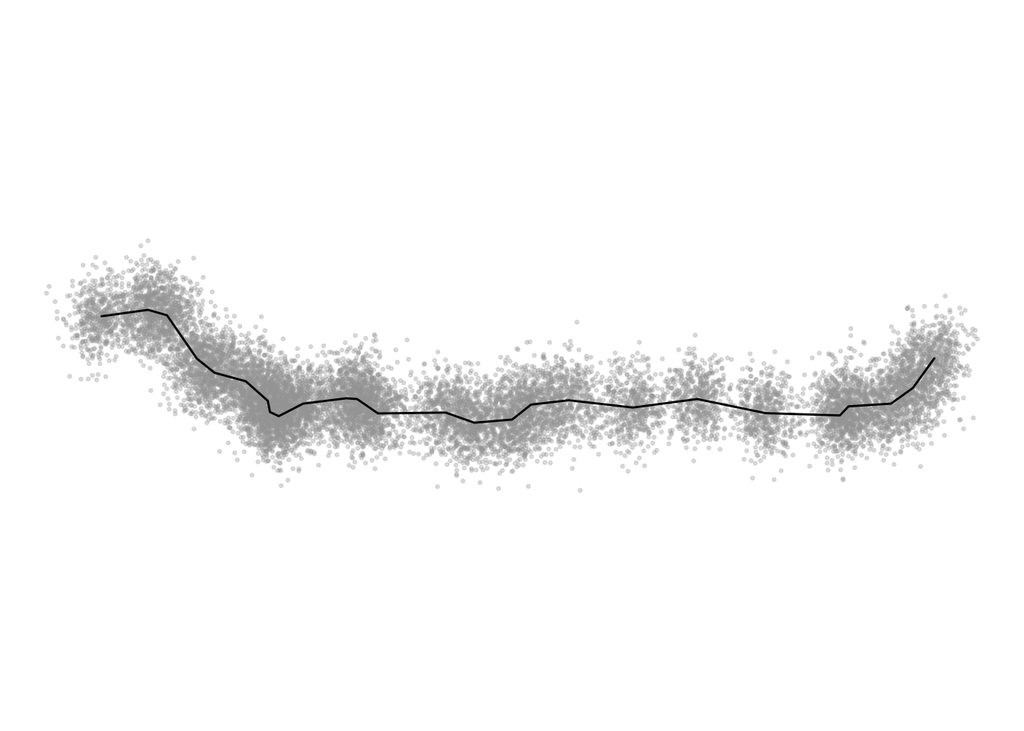

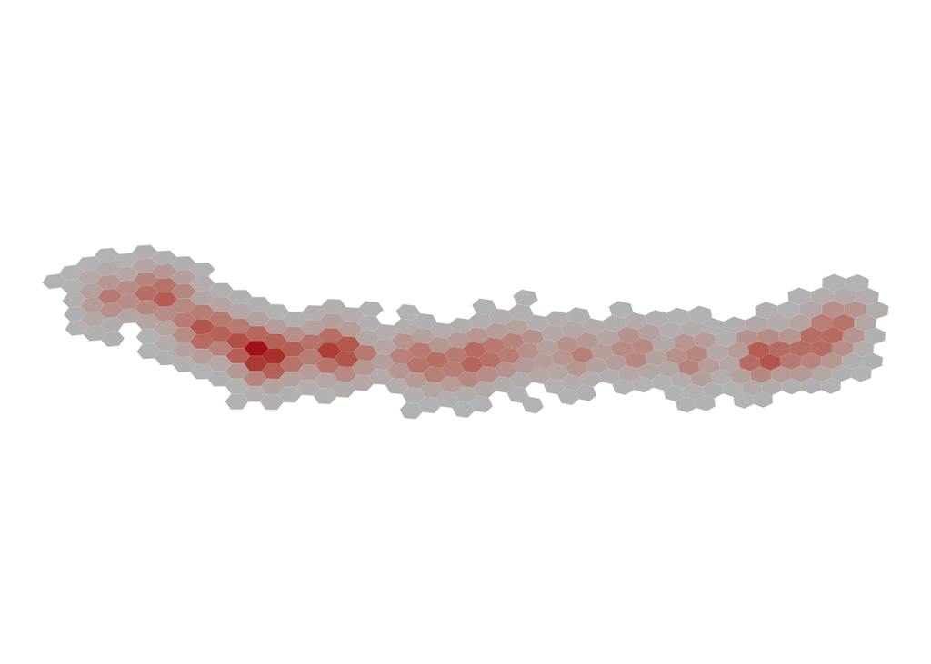

## Model Construction

A model is created that uses the *current* geohash to predict the *next* geohash. The “model” in this case is really just a collection of hex-pairs plus the number of times this pair was seen in the data.

```r
# Create hex pairs: hex to next-hex
model_stuff <- function(df) {
  df %>% rename(hex0=hex) %>%
    mutate(hex1 = lead(hex0, n=1), n=1)
}

# Build the correlation model
df.mod <- df.dat %>%
  dplyr::select(idx_tr, idx_pt, hex) %>%
  tidyr::nest(data=c(idx_pt,hex)) %>%
  mutate(data = purrr::map(data,model_stuff)) %>%
  unnest(cols=c(data)) %>%
  group_by(hex0,hex1) %>%
  summarise(w = sum(n)) %>%
  ungroup()
```

## Monte Carlo

Next, a driver function is created that will run the monte carlo process to completion. In other words, the function takes a starting point and uses the model generated above to probabilistically determine which hex to land on next. The process continues until either the end is reached or the maximum number of iterations is reached.

```r
# Pick the next hex based on the present hex
random_picker <- function(hex, df.model) {
  df <- df.model %>% filter(hex0==hex) #%>% mutate(z=w/sum(w))
  df$z <- df$w/sum(df$w)
  if (nrow(df) > 0) {
    hx <- sample(df$hex1, 1, prob=df$z)
  } else {hx <- NA}
}

# Get all the possible start points
start_points <- df.dat %>%
  filter(idx_pt == 1) %>%
  group_by(hex) %>%
  count()
start_points$r <- start_points$n/sum(start_points$n)


# Monte Carlo function
my_monte_carlo <- function(start, max_iter, df.model) {
  d <- list()
  d[[1]] <- start
  for (i in 2:max_iter) {
    hex_new <- d[[i-1]]
    d[[i]] <- random_picker(hex_new, df.model)
    if (is.na(d[[i]])) {break}
  }
  M <- length(d)
  data.frame(idx=1:M, hex=unlist(d)) %>%
    filter(!is.na(hex)) %>%
    mutate(geometry = h3::h3_to_geo_boundary_sf(hex) %>% pull(geometry),
           pt = sf::st_centroid(geometry))
}
```

To run the monte carlo, a starting point is selected from a random sample of starting points seen in the data. The function then traces a likely path based on correlations included in the supplied model. The result is a single path derived from the monte carlo model,

```r
# Get a random start point
fstart <- sample(start_points$hex, 1, prob=start_points$r)
df.mte <- my_monte_carlo(fstart, max_iter=30, df.mod)
ln2 <- df.mte %>% pull(pt) %>% sf::st_coordinates() %>% make_line() %>% sf::st_sfc(crs=4326)
```

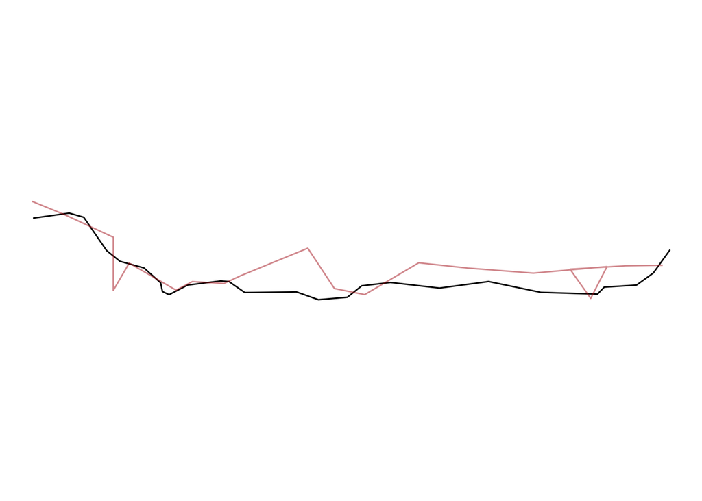

Now we can run the simulation as many times as we want,

```r
N <- 10
fstart <- sample(start_points$hex, N, prob=start_points$r)
dd <- lapply(1:N, function(i) {
  my_monte_carlo(fstart[i], max_iter=30, df.mod) %>% mutate(nn = i)
})
df.mte2 <- do.call(rbind,dd) %>%
  group_by(nn) %>%
  summarise(ln = sf::st_coordinates(pt) %>% make_line() %>% sf::st_sfc(crs=4326))
```

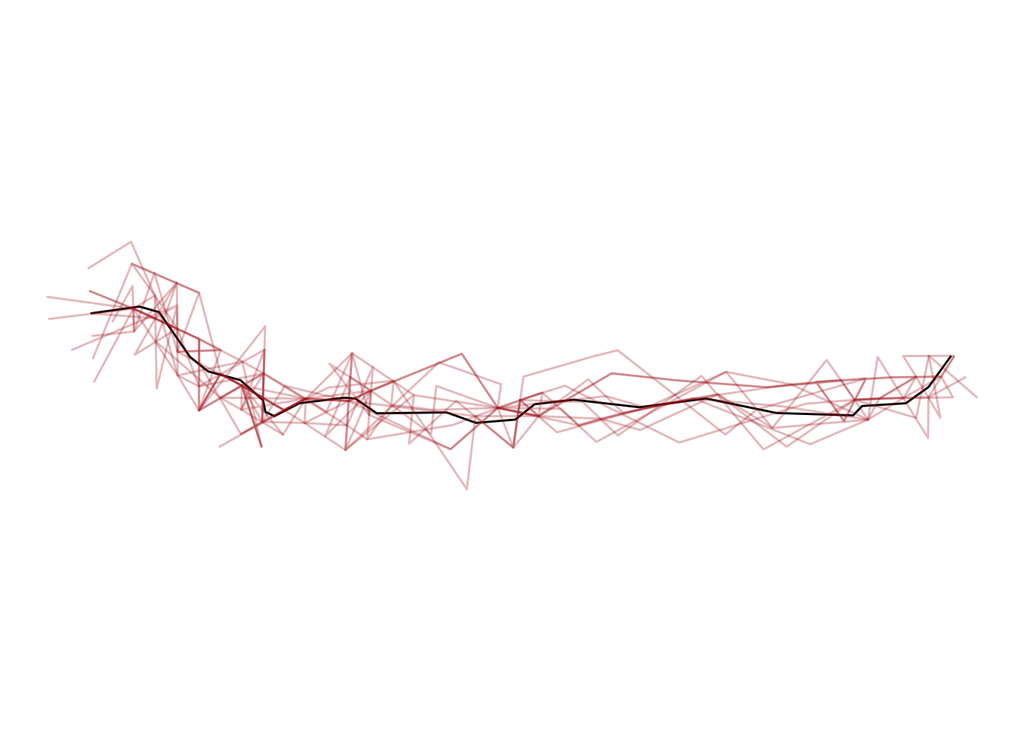

## Next-Hex Probabilities

With the model constructed above it is straightforward to simply plot the next-hex probabilities given some current geohash position,

```r
set.seed(1234)
fstart <- sample(start_points$hex, 1, prob=start_points$r)
dfx <- df.mod %>% filter(hex0==fstart)
dfx$z <- dfx$w/sum(dfx$w)

df.prb <- dfx %>%
  mutate(geometry = h3::h3_to_geo_boundary_sf(hex1) %>% pull(geometry))
```

In the example below, the current-hex is depicted in black, and the next-hex probabilities are represented by fill color in the surrounding geohashes,

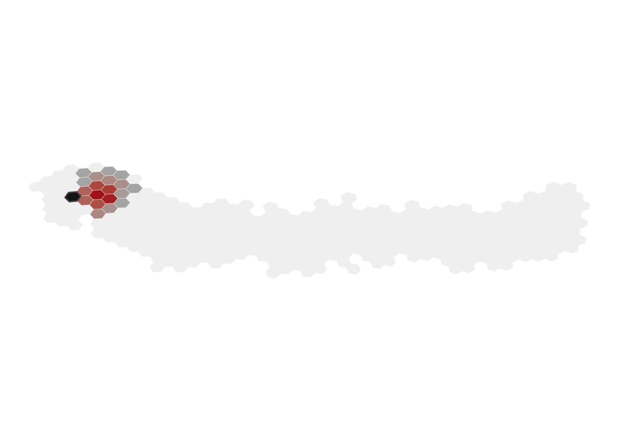

## References

[h3 package](https://crazycapivara.github.io/h3-r/articles/h3.html)